# Objetivo_2

Víctor

2025-05-21

```r
library(readr)
gen <- read_csv("generacion_todas_comunidades.csv", show_col_types = FALSE)
```

```r
library(dplyr)
```

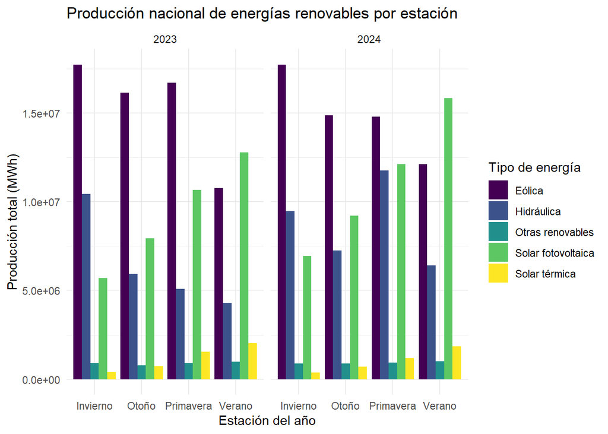

```r
library(ggplot2)
library(lubridate)
# Definir las estaciones
asignar_estacion <- function(mes) {
  case_when(
    mes %in% c(12, 1, 2)  ~ "Invierno",
    mes %in% 3:5          ~ "Primavera",
    mes %in% 6:8          ~ "Verano",
    mes %in% 9:11         ~ "Otoño",
    TRUE ~ NA_character_
  )
}

# Preparar datos
renovables_trimestre <- gen %>%
  filter(variable %in% c("Eólica", "Solar fotovoltaica", "Solar térmica", "Hidráulica", "Otras renovables")) %>%
  mutate(
    año = year(fecha),
    mes = month(fecha),
    estacion = asignar_estacion(mes)
  ) %>%
  group_by(año, estacion, variable) %>%
  summarise(produccion_total = sum(valor, na.rm = TRUE), .groups = "drop")

# Gráfico de barras
ggplot(renovables_trimestre, aes(x = estacion, y = produccion_total, fill = variable)) +
  geom_col(position = "dodge") +
  facet_wrap(~ año) +
  labs(
    title = "Producción nacional de energías renovables por estación",
    x = "Estación del año",
    y = "Producción total (MWh)",
    fill = "Tipo de energía"
  ) +
  theme_minimal() +
  scale_fill_viridis_d()
```

Este gráfico muestra la producción de diferentes tipos de energías renovables en España, desglosada por estaciones del año y años.

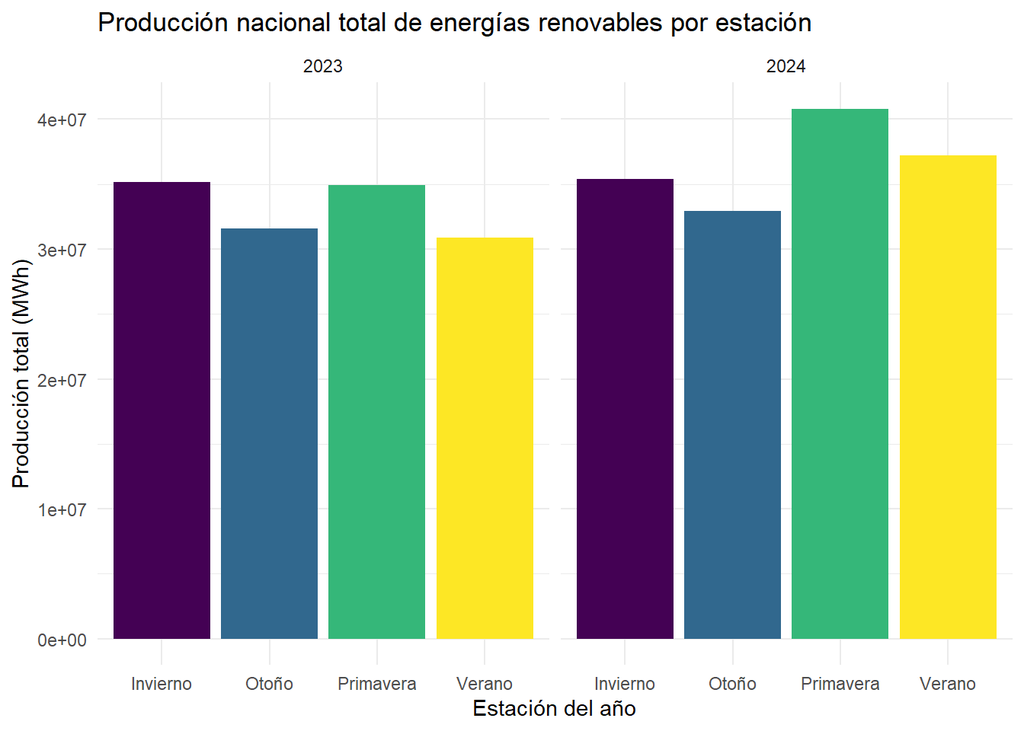

```r
asignar_estacion <- function(mes) {
  case_when(
    mes %in% c(12, 1, 2)  ~ "Invierno",
    mes %in% 3:5          ~ "Primavera",
    mes %in% 6:8          ~ "Verano",
    mes %in% 9:11         ~ "Otoño",
    TRUE ~ NA_character_
  )
}

# Preparar datos agregados
renovables_total_estacion <- gen %>%
  filter(variable %in% c("Eólica", "Solar fotovoltaica", "Solar térmica", "Hidráulica", "Otras renovables")) %>%
  mutate(
    año = year(fecha),
    mes = month(fecha),
    estacion = asignar_estacion(mes)
  ) %>%
  group_by(año, estacion) %>%
  summarise(produccion_total = sum(valor, na.rm = TRUE), .groups = "drop")

# Gráfico
ggplot(renovables_total_estacion, aes(x = estacion, y = produccion_total, fill = estacion)) +
  geom_col() +
  facet_wrap(~ año) +
  labs(
    title = "Producción nacional total de energías renovables por estación",
    x = "Estación del año",
    y = "Producción total (MWh)"
  ) +
  theme_minimal() +
  scale_fill_viridis_d() +
  theme(legend.position = "none")
```

Este gráfico muestra la producción total de energías renovables en España, desglosada por estaciones del año y años.

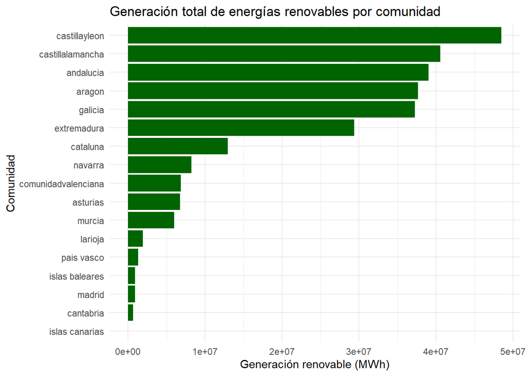

```r
renovables <- gen %>%
  filter(variable %in% c("Eólica", "Solar fotovoltaica", "Solar térmica", "Hidráulica", "Otras renovables")) %>%
  mutate(comunidad = tolower(comunidad))

renovables_comunidad <- renovables %>%
  group_by(comunidad) %>%
  summarise(generacion_renovable_total = sum(valor, na.rm = TRUE)) %>%
  arrange(desc(generacion_renovable_total))

ggplot(renovables_comunidad, aes(x = reorder(comunidad, generacion_renovable_total), y = generacion_renovable_total)) +
  geom_col(fill = "darkgreen") +
  coord_flip() +
  labs(
    title = "Generación total de energías renovables por comunidad",
    x = "Comunidad", y = "Generación renovable (MWh)"
  ) +
  theme_minimal()
```

Las comunidades que más destacan por su producción energética mediante energías renovables son Castilla y León, Castilla-La Mancha, Andalucía, Aragón y Galicia.

```r
library(shiny)
library(tidyr)

data <- read_csv("generacion_todas_comunidades.csv") %>%
  rename(
    Energia = variable,
    Comunidad = comunidad,
    Generacion = valor,
    Fecha = fecha
  ) %>%
  mutate(
    Fecha    = ymd(Fecha),
    Año      = year(Fecha),
    Mes      = month(Fecha),
    MesLabel = month(Fecha, label = TRUE, abbr = TRUE)
  )
```

```r
# Colores personalizados por tipo de energía
colores_energia <- c(
  "Eólica"             = "#F8766D",
  "Solar fotovoltaica" = "#00BFC4",
  "Hidráulica"         = "#FFDE00",
  "Otras renovables"   = "#C77CFF",
  "Solar térmica"      = "#7CAE00"
)

# Interfaz de usuario
ui <- fluidPage(
  titlePanel("Dashboard: Generación de Energías Renovables en España"),
  sidebarLayout(
    sidebarPanel(
      selectInput("comunidad", "Comunidad Autónoma:",
                  choices = c("España (nacional)", unique(data$Comunidad))),
      selectInput("anio", "Año:",
                  choices = sort(unique(data$Año))),
      selectInput("energia", "Tipo de Energía:",
                  choices = c("Total Renovables", names(colores_energia)))
    ),
    mainPanel(
      plotOutput("plotGeneracion", height = "500px"),
      br(),
      h4("Correlación con otras energías renovables"),
      plotOutput("plotCorrelacion", height = "400px")
    )
  )
)

# Lógica del servidor
server <- function(input, output, session) {

  # Dataset filtrado para gráfico principal
  datosFiltrados <- reactive({
    req(input$comunidad, input$anio, input$energia)

    base <- data %>%
      filter(
        Año == input$anio,
        if (input$comunidad != "España (nacional)") Comunidad == input$comunidad else TRUE
      )

    if (input$energia == "Total Renovables") {
      base %>%
        filter(Energia %in% names(colores_energia)) %>%
        group_by(MesLabel, Mes) %>%
        summarise(Generacion = sum(Generacion, na.rm = TRUE), .groups = "drop") %>%
        mutate(Energia = "Total Renovables", Comunidad = input$comunidad)
    } else {
      base %>%
        filter(Energia == input$energia)
    }
  })

  # Gráfico de generación mensual SIN LEYENDA
  output$plotGeneracion <- renderPlot({
    df <- datosFiltrados()

    validate(
      need(nrow(df) > 0, "⚠️ No hay datos para la energía, comunidad y año seleccionados.")
    )

    ggplot(df, aes(x = MesLabel, y = Generacion, fill = Energia)) +
      geom_col(position = "stack", show.legend = FALSE) +
      scale_fill_manual(values = c(colores_energia, "Total Renovables" = "darkgreen")) +
      labs(
        x = "Mes",
        y = "Generación (MWh)",
        title = paste("Generación Mensual -", input$comunidad, input$anio),
        subtitle = input$energia
      ) +
      theme_minimal() +
      theme(legend.position = "none")
  })

  # Matriz de correlación entre energías renovables
  matrizCorrelacion <- reactive({
    req(input$comunidad, input$anio)

    energias_renovables <- names(colores_energia)

    df_filtrado <- if (input$comunidad == "España (nacional)") {
      data %>%
        filter(
          Año == input$anio,
          Energia %in% energias_renovables
        ) %>%
        group_by(MesLabel, Energia) %>%
        summarise(Generacion = sum(Generacion, na.rm = TRUE), .groups = "drop")
    } else {
      data %>%
        filter(
          Comunidad == input$comunidad,
          Año == input$anio,
          Energia %in% energias_renovables
        ) %>%
        group_by(MesLabel, Energia) %>%
        summarise(Generacion = sum(Generacion, na.rm = TRUE), .groups = "drop")
    }

    df_wide <- df_filtrado %>%
      pivot_wider(names_from = Energia, values_from = Generacion) %>%
      select(-MesLabel)

    df_wide <- df_wide[, colSums(!is.na(df_wide)) > 1, drop = FALSE]
    if (ncol(df_wide) > 1) cor(df_wide, use = "pairwise.complete.obs") else NULL
  })

  # Gráfico de correlación con otras energías
  output$plotCorrelacion <- renderPlot({
    if (input$energia == "Total Renovables") {
      plot.new()
      title("Selecciona una energía individual para ver su correlación.")
      return()
    }

    matriz <- matrizCorrelacion()
    energia_base <- input$energia

    validate(
      need(!is.null(matriz), "⚠️ No hay datos suficientes para calcular correlaciones."),
      need(energia_base %in% rownames(matriz), "⚠️ No se puede calcular correlación para esta energía.")
    )

    cor_vector <- matriz[energia_base, ]
    cor_filtrada <- data.frame(
      Energía = names(cor_vector),
      Correlación = as.numeric(cor_vector)
    ) %>%
      filter(Energía != energia_base)

    validate(
      need(nrow(cor_filtrada) > 0, "⚠️ No hay otras energías con las que correlacionar.")
    )

    ggplot(cor_filtrada, aes(x = reorder(Energía, Correlación), y = Correlación, fill = Energía)) +
      geom_col(show.legend = FALSE) +
      coord_flip() +
      scale_fill_manual(values = colores_energia) +
      labs(
        title = paste("Correlación con", energia_base),
        subtitle = paste("Año", input$anio, "-", input$comunidad),
        x = NULL,
        y = "Correlación"
      ) +
      theme_minimal()
  })
}

# Ejecutar app
shinyApp(ui, server)
```

Shiny applications not supported in static R Markdown documents

Esta app nos permite observar la generación de energía mediante energías renovables en España, tanto a nivel nacional como por comunidad autónoma. Podemos seleccionar el tipo de energía y el año para ver la producción dividida en meses. Además, se incluye un gráfico que muestra la correlación entre diferentes tipos de energías renovables para el año y comunidad seleccionados.

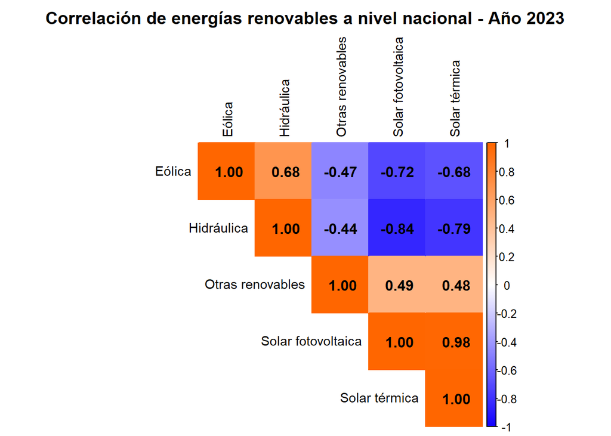

```r
library(corrplot)
renovables <- c("Eólica", "Hidráulica", "Solar fotovoltaica", "Solar térmica", "Otras renovables")

# Preparar los datos
gen_clean <- gen %>%
  rename(
    Comunidad = comunidad,
    Fecha = fecha,
    Energia = variable,
    Generacion = valor
  ) %>%
  mutate(Fecha = ymd(Fecha)) %>%
  filter(Energia %in% renovables)

calcular_correlacion_anual <- function(datos, año) {
  datos %>%
    filter(year(Fecha) == año) %>%
    group_by(Mes = month(Fecha), Energia) %>%
    summarise(Generacion = sum(Generacion, na.rm = TRUE), .groups = "drop") %>%
    pivot_wider(names_from = Energia, values_from = Generacion) %>%
    select(-Mes) %>%
    cor(use = "pairwise.complete.obs")
}

# Matrices de correlación
cor_2023 <- calcular_correlacion_anual(gen_clean, 2023)
cor_2024 <- calcular_correlacion_anual(gen_clean, 2024)

colores_personalizados <- colorRampPalette(c("#1100FF", "white", "#FF6600"))(200)

# 2023
corrplot(cor_2023,
         method = "color",
         type = "upper",
         col = colores_personalizados,
         tl.col = "black",
         tl.cex = 0.9,
         title = "Correlación de energías renovables a nivel nacional - Año 2023",
         mar = c(0,0,2,0),
         addCoef.col = "black")
```

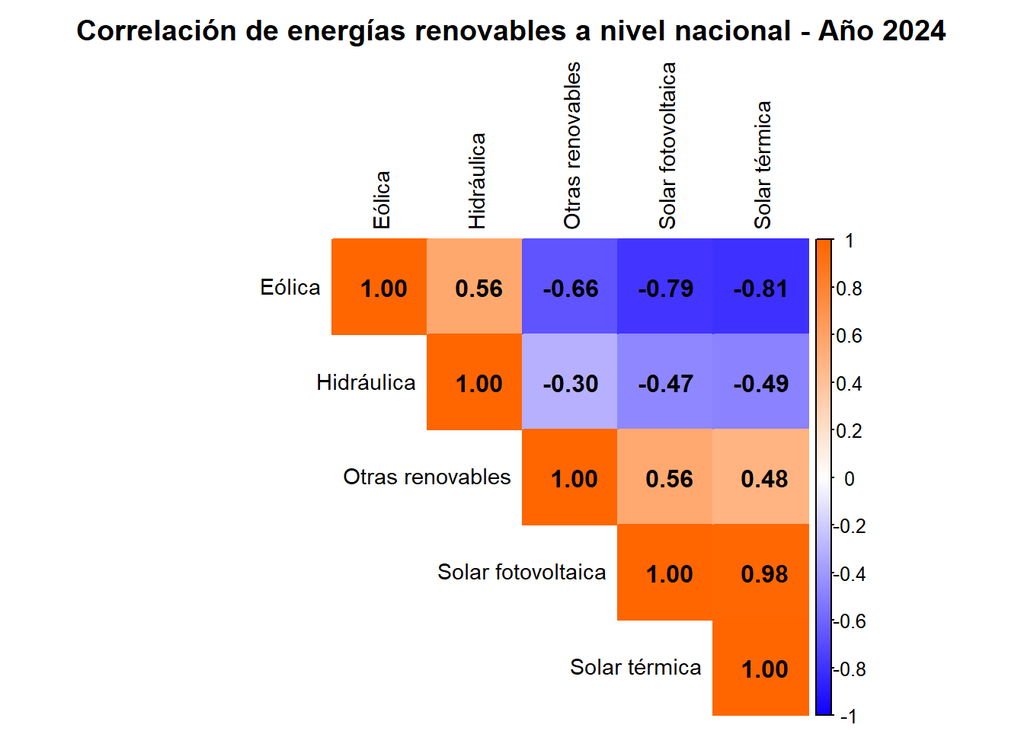

```r
# 2024
corrplot(cor_2024,
         method = "color",
         type = "upper",
         col = colores_personalizados,
         tl.col = "black",
         tl.cex = 0.9,
         title = "Correlación de energías renovables a nivel nacional - Año 2024",
         mar = c(0,0,2,0),
         addCoef.col = "black")
```

Estas son las matrices de correlación de las energías renovables a nivel nacional.

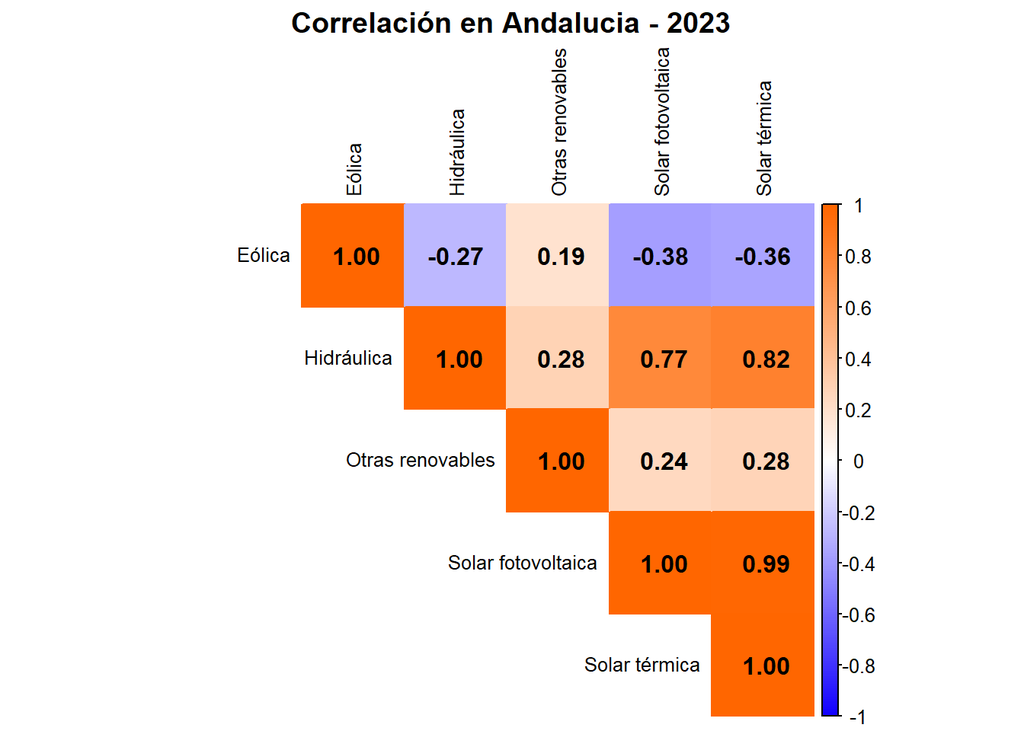

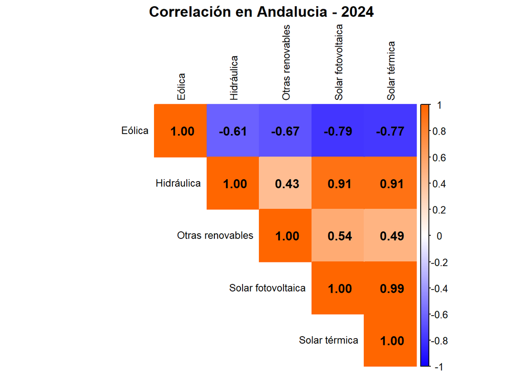

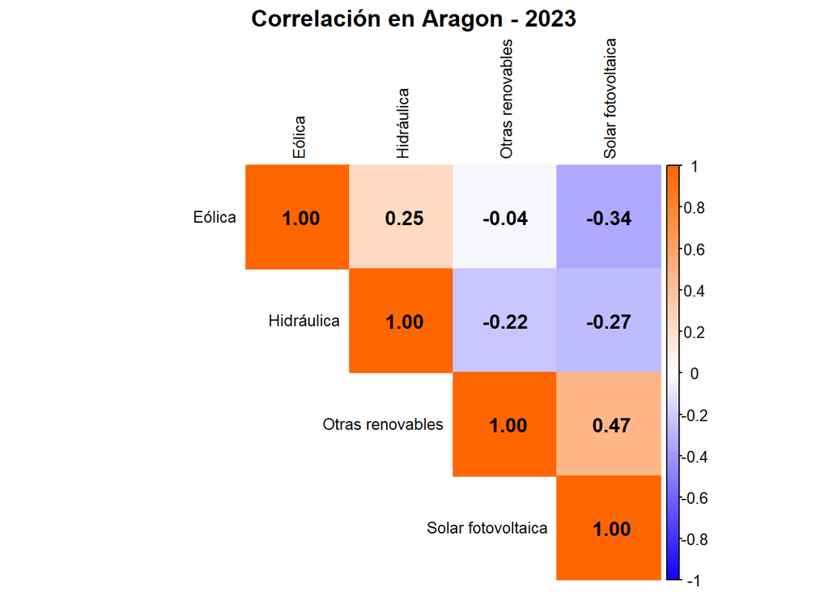

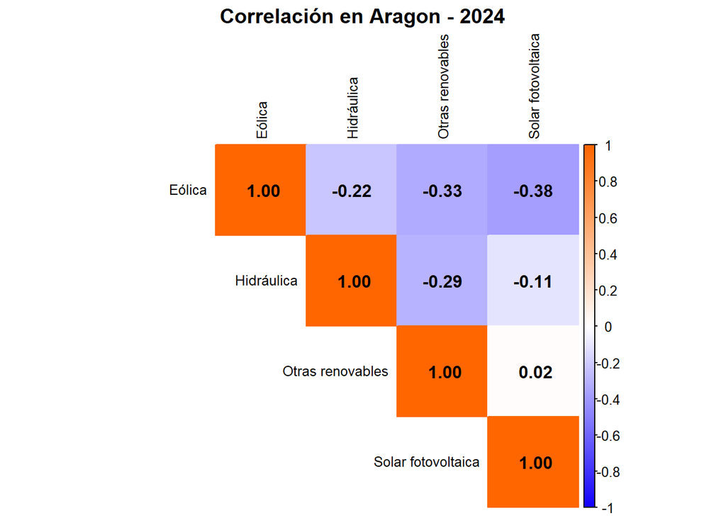

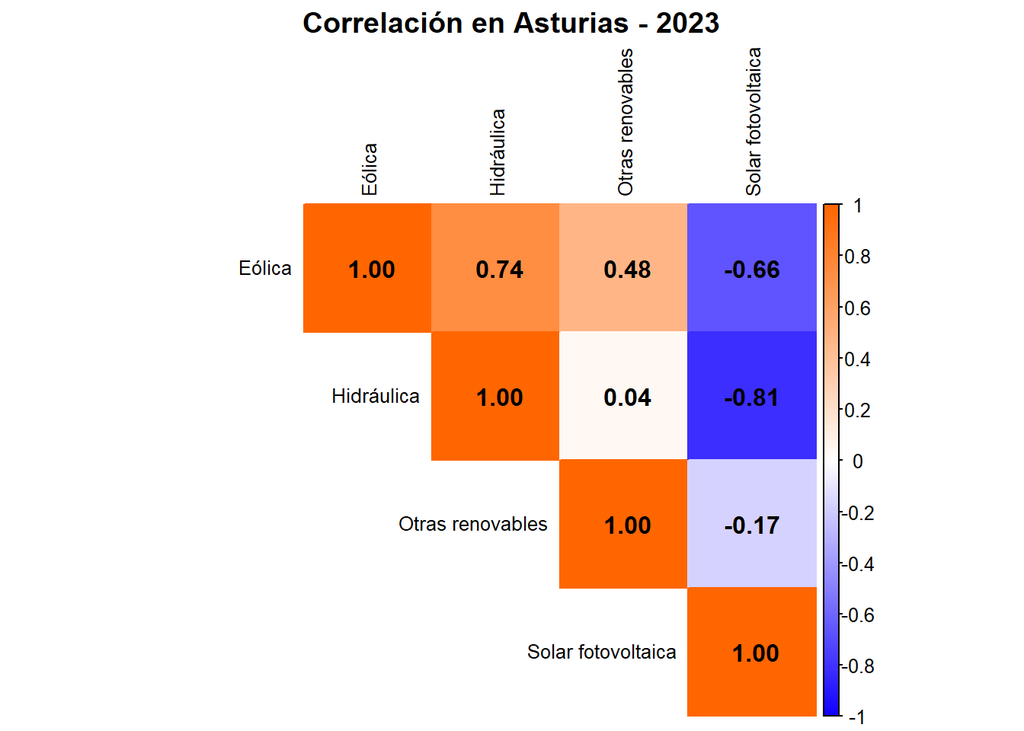

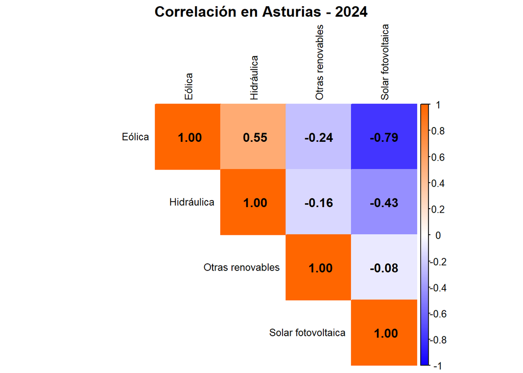

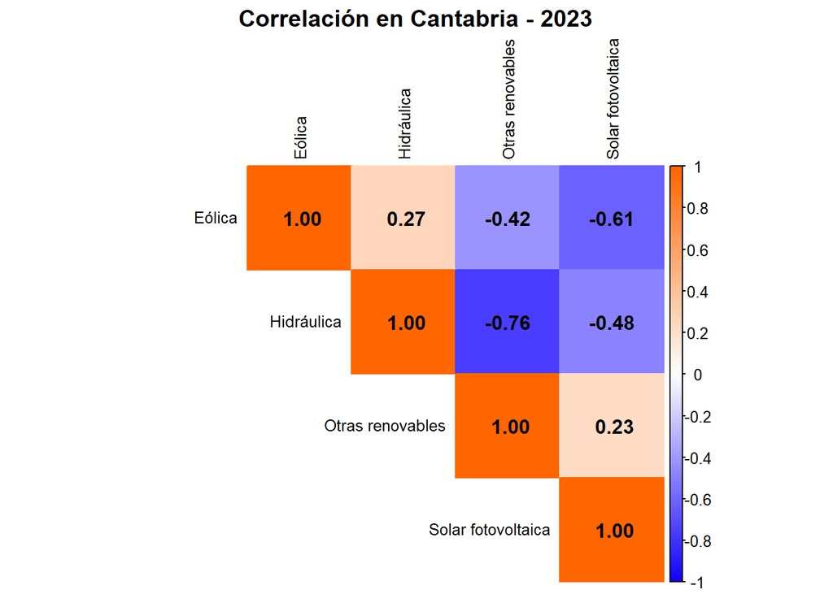

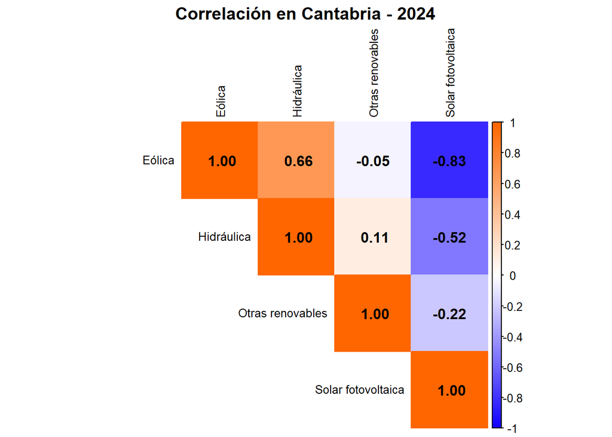

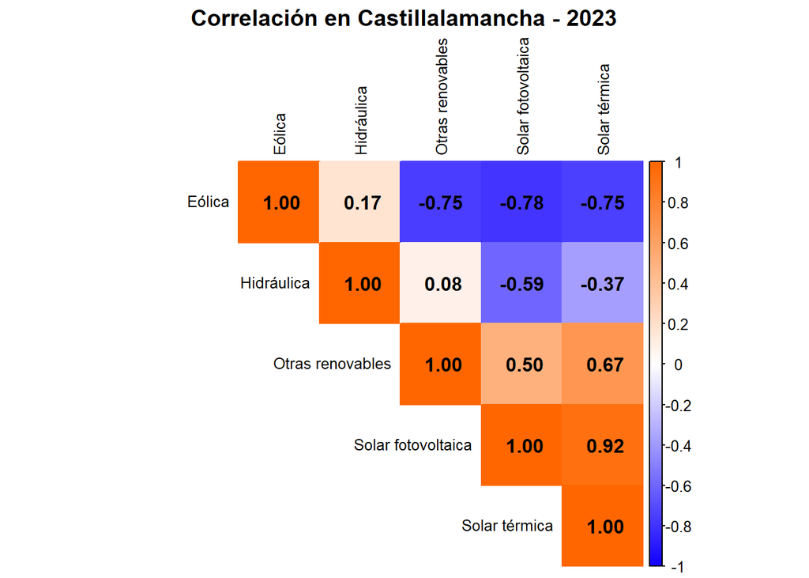

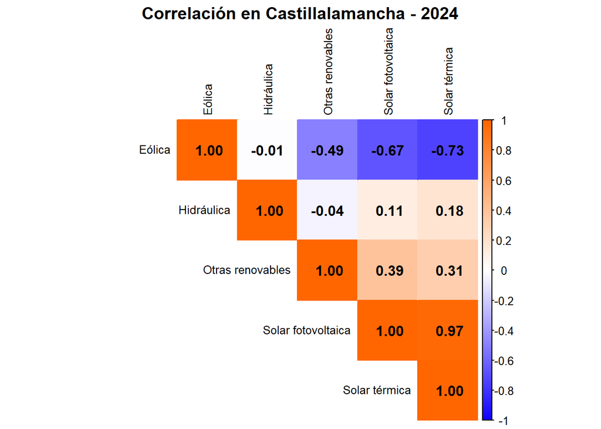

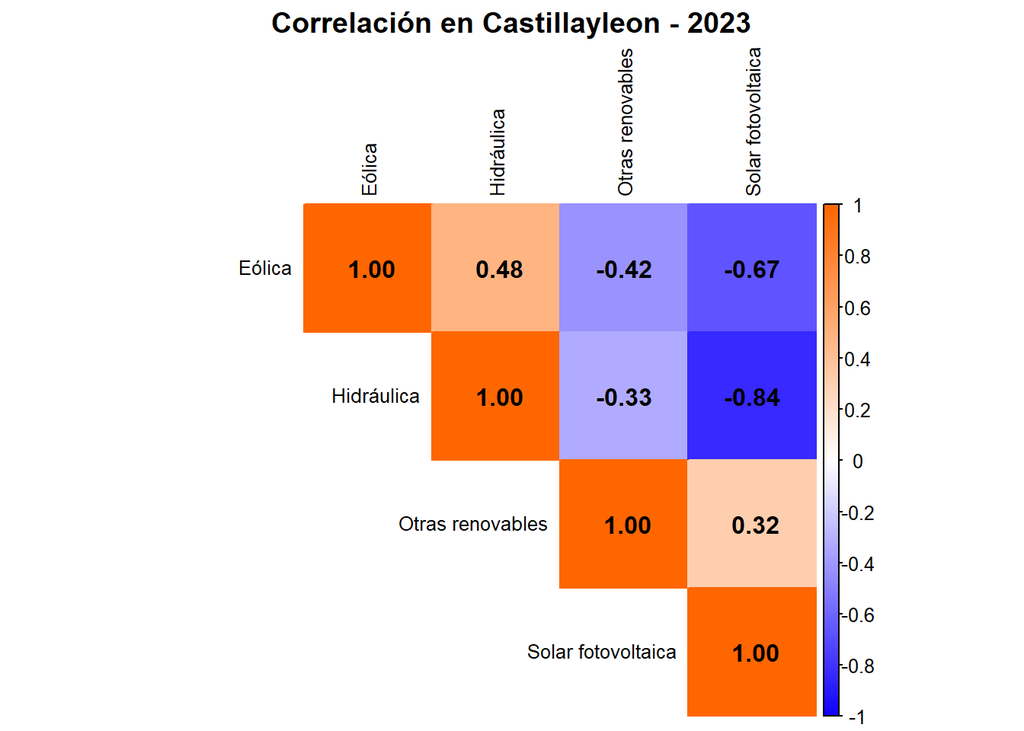

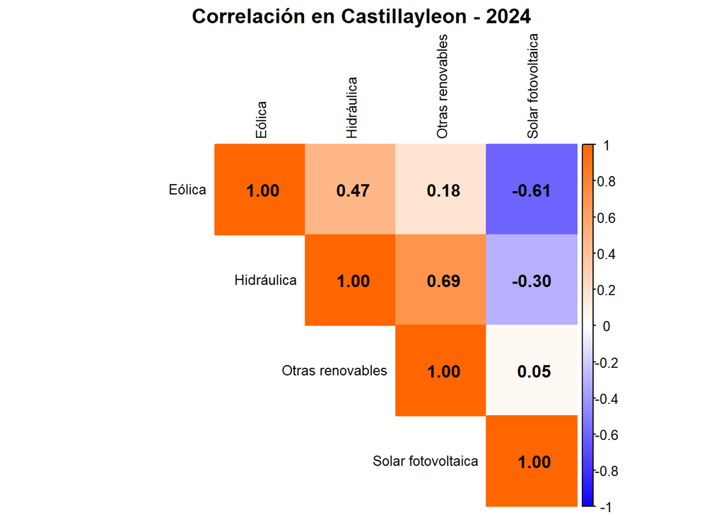

[20 more figures not shown]

```r
library(corrplot)

colores_personalizados <- colorRampPalette(c("#1100FF", "white", "#FF6600"))(200)

renovables <- c("Eólica", "Hidráulica", "Solar fotovoltaica", "Solar térmica", "Otras renovables")

comunidades <- unique(gen_clean$Comunidad)
anios <- c(2023, 2024)

# Iterar por comunidad y año
for (com in comunidades) {
  for (anio in anios) {

    df_comunidad_anio <- gen_clean %>%
      filter(
        Comunidad == com,
        Energia %in% renovables,
        year(Fecha) == anio
      ) %>%
      mutate(Mes = month(Fecha)) %>%
      group_by(Mes, Energia) %>%
      summarise(Generacion = sum(Generacion, na.rm = TRUE), .groups = "drop") %>%
      pivot_wider(names_from = Energia, values_from = Generacion)

    # Seleccionar columnas válidas
    columnas_validas <- colnames(df_comunidad_anio)[colnames(df_comunidad_anio) %in% renovables]
    df_filtrado <- df_comunidad_anio[, columnas_validas]

    # Comprobar desviación estándar
    columnas_sd_ok <- sapply(df_filtrado, sd, na.rm = TRUE) != 0
    df_filtrado <- df_filtrado[, columnas_sd_ok]

    if (ncol(df_filtrado) >= 2) {
      cor_com <- cor(df_filtrado, use = "pairwise.complete.obs")

      corrplot(cor_com,
               method = "color",
               type = "upper",
               col = colores_personalizados,
               tl.col = "black",
               tl.cex = 0.8,
               title = paste("Correlación en", com, "-", anio),
               mar = c(0, 0, 1.5, 0),
               addCoef.col = "black")

      Sys.sleep(1)
    } else {
      message("No hay suficientes energías con variabilidad en ", com, " - ", anio)
    }
  }
}
```

Estas son las matrices de correlación entre las energías renovables de las diferentes comunidades autónomas en 2023 y 2024.

```r
library(sf)
library(stringr)
library(viridis)
```

```r
estaciones <- list(
  "Invierno (DIC-ENE-FEB)" = c(12, 1, 2),
  "Primavera (MAR-ABR-MAY)" = 3:5,
  "Verano (JUN-JUL-AGO)" = 6:8,
  "Otoño (SEP-OCT-NOV)" = 9:11,
  "Todo el año" = 1:12
)

energias_renovables <- c("Eólica", "Solar fotovoltaica", "Solar térmica", "Hidráulica", "Otras renovables")

ui <- fluidPage(
  titlePanel("Generación Renovable por Comunidad y Estación"),
  sidebarLayout(
    sidebarPanel(
      selectInput("año", "Selecciona el año:", choices = NULL),
      selectInput("trimestre", "Selecciona la estación:", choices = names(estaciones)),
      selectInput("energia", "Selecciona energía:", choices = c("Total Renovables", energias_renovables))
    ),
    mainPanel(
      plotOutput("mapa")
    )
  )
)

server <- function(input, output, session) {

  gen <- read.csv("generacion_todas_comunidades.csv") # o tu origen real
  gen <- gen %>%
    filter(variable %in% energias_renovables) %>%
    rename(Energia = variable, Comunidad = comunidad, Generacion = valor, Fecha = fecha) %>%
    mutate(
      Fecha = ymd(Fecha),
      año = year(Fecha),
      mes = month(Fecha),
      comunidad = tolower(Comunidad) #stringr
    )

  nombre_normalizado <- c(
    "andalucia" = "Andalucía", "aragon" = "Aragón", "asturias" = "Principado de Asturias",
    "cantabria" = "Cantabria", "castillalamancha" = "Castilla-La Mancha",
    "castillayleon" = "Castilla y León", "cataluna" = "Cataluña",
    "comunidadvalenciana" = "Comunidad Valenciana", "extremadura" = "Extremadura",
    "galicia" = "Galicia", "islasbaleares" = "Islas Baleares",
    "islascanarias" = "Canarias", "larioja" = "La Rioja",
    "madrid" = "Comunidad de Madrid", "murcia" = "Región de Murcia",
    "navarra" = "Comunidad Foral de Navarra", "pais vasco" = "País Vasco"
  )

  mapa_ccaa <- st_as_sf(mapa_ccaa) #agrupo como variable sf

  observe({
    updateSelectInput(session, "año", choices = sort(unique(gen$año)))
  })

  output$mapa <- renderPlot({
    meses <- estaciones[[input$trimestre]]

    datos_filtrados <- gen %>%
      filter(año == input$año, mes %in% meses)

    if (input$energia == "Total Renovables") {
      datos_agg <- datos_filtrados %>%
        group_by(comunidad) %>%
        summarise(generacion_renovable_total = sum(Generacion, na.rm = TRUE), .groups = "drop")
    } else {
      datos_agg <- datos_filtrados %>%
        filter(Energia == input$energia) %>%
        group_by(comunidad) %>%
        summarise(generacion_renovable_total = sum(Generacion, na.rm = TRUE), .groups = "drop")
    }

    datos_agg <- datos_agg %>%
      mutate(NAME_1 = nombre_normalizado[comunidad])

    mapa_datos <- mapa_ccaa %>%
      left_join(datos_agg, by = "NAME_1")

    ggplot(mapa_datos) +
      geom_sf(aes(fill = generacion_renovable_total), color = "white") +
      scale_fill_viridis_c(option = "C", name = "Generación (MWh)", direction = -1, na.value = "gray90") +
      labs(
        title = paste("Generación de", input$energia, "en", input$año, "-", input$trimestre),
        caption = "Fuente: Datos balance energético + elaboración propia"
      ) +
      theme_minimal()
  })
}

shinyApp(ui = ui, server = server)
```

Shiny applications not supported in static R Markdown documents

En esta aplicación podemos ver la producción de las diferentes energías renovables en el mapa de España desglosada por estación del año y año.